# Assignment-1

Ankit kumar

04/03/2022

## Q1

```r
movies = read.csv("D:/Downloads/Q1_MA5755_2.csv")

summary(movies)
```

```
##   TV.series         Time.series..min  Time.series.       movies
##  Length:10          Min.   : 300.0   Min.   : 5.000   Length:10
##  Class :character   1st Qu.: 382.5   1st Qu.: 6.375   Class :character
##  Mode  :character   Median : 840.0   Median :14.000   Mode  :character
##                     Mean   : 985.5   Mean   :16.425
##                     3rd Qu.:1432.5   3rd Qu.:23.875
##                     Max.   :2255.0   Max.   :37.583
##  TIme.movies..min  TIme.movies.
##  Min.   :116.0    Min.   :1.933
##  1st Qu.:148.0    1st Qu.:2.467
##  Median :154.5    Median :2.575
##  Mean   :155.6    Mean   :2.593
##  3rd Qu.:169.8    3rd Qu.:2.829
##  Max.   :182.0    Max.   :3.033
```

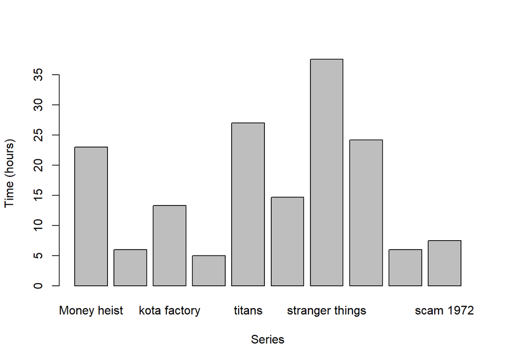

```r
barplot(movies$Time.series.,names.arg=movies$TV.series,xlab = "Series",
        ylab = "Time (hours)")
```

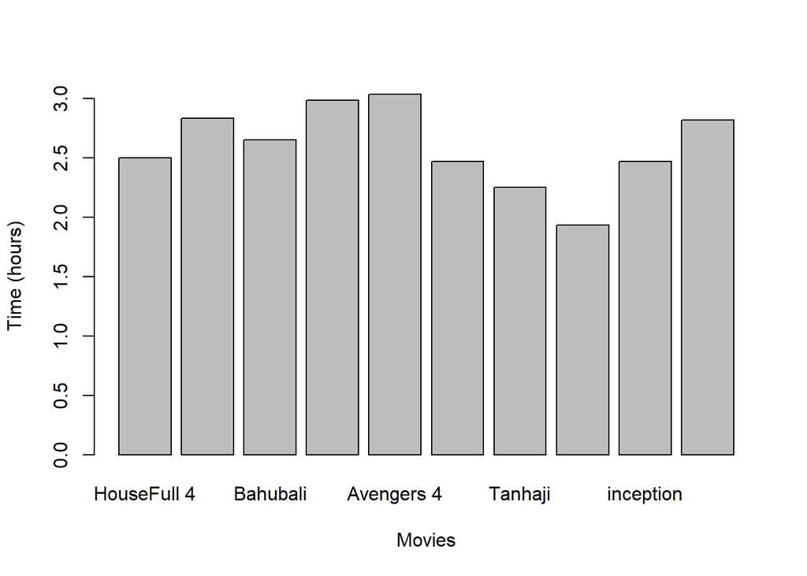

```r
barplot(movies$TIme.movies.,names.arg=movies$movies,xlab = "Movies",
        ylab = "Time (hours)")
```

## Q2

```
##   Timestamp         Time.max.concentration.
##  Length:20          Min.   : 400
##  Class :character   1st Qu.:1000
##  Mode  :character   Median :1800
##                     Mean   :1531
##                     3rd Qu.:2032
##                     Max.   :2359
```

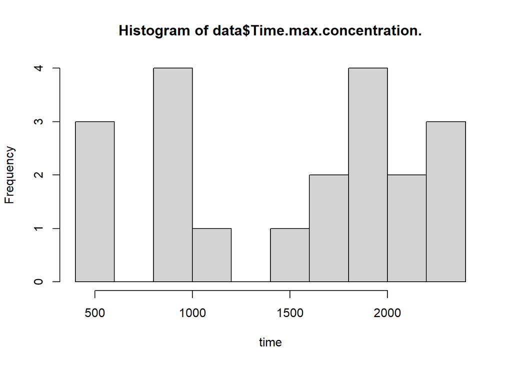

From histogram plot , we can see that maximum people felt that their concentration are high at evening. so for Group study **18:00 to 23:00** will be best

## Q3

X = features  
c = no of categories $\omega_{1}$, $\omega_{2}$, …, $\omega_{3}$  
l = no of actions $\alpha_{1}$ , $\alpha_{2}$ , … , $\alpha_{l}$  
loss function = $\lambda(\alpha_{i}/ \omega_{j})$ - the cost associated with taking action $\alpha_{i}$ when the correct classification category is $\omega_{j}$  
Suppose for x and we have taken action $\alpha_{i}$ and that the cost associated with taking action $\alpha_{i}$ with $\omega_{j}$ being the correct category is $\lambda(\alpha_{i}/ \omega_{j})$  
The conditional risk (or expected loss) with taking action $\alpha_{i}$ is:

$$\sum_{j=1}^{c} \lambda
(a_{i}/\omega_{j}) P(\omega_{j}/ x)$$
Put , loss function as following,
$$\lambda(a_{i}/\omega_{j})=
\begin{cases}
0 \quad &amp;\text{if} \, i=j \\
1 \quad &amp;\text{if} \, i\neq j \\
\end{cases}$$

Hence for zero-one loss, the conditional risk corresponding to this loss function:
$$R(a_{i}/X) =
\sum_{j=1}^{c}\lambda(a_{i}/\omega_{j})P(\omega_{j}/X)= \sum_{i\neq
j}P(\omega_{j}/x)=1-P(\omega_{i}/x)$$

For zero-one loss function, the decision rule becomes:  
Decide $\omega_{1}$ if $R(a_{1}/X)$ < $R(a_{2}/X);$ otherwise decide $\omega_{2}$  
or  
Decide $\omega_{1}$ if 1-$P(\omega_{1}/X)$ < 1 - $P(\omega_{2}/X);$ otherwise decide $\omega_{2}$  
or  
Decide $\omega_{1}$ if $P(\omega_{1}/X)$ > $P(\omega_{2}/X);$ otherwise decide $\omega_{2}$  
Hence in this case, the overall risk is the average probability error.

## Q4

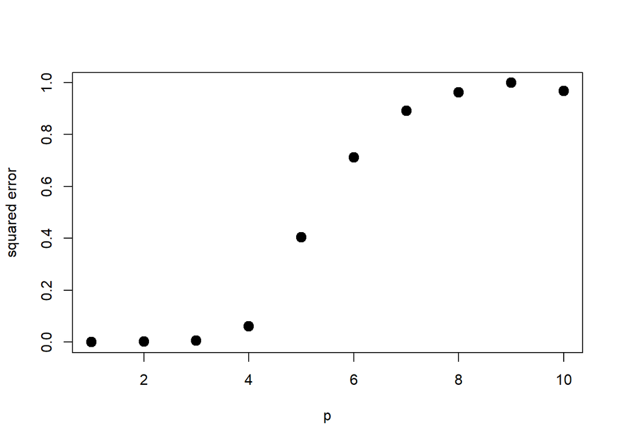

```r
library(class)
x_test_1 = 0
Y_test_1 = exp(-8*x_test_1)
X = NULL
sq_error = NULL


for (p in 1:10) {
  X = NULL
  for (x in 1:1000) {

    X1 = 0
    for (q in 1:p) {
      X2 = runif(1,min=-1,max=1)^2
      X1 = X1 + X2

    }

    X = c(X,X1)
  }

  Y = exp(-8*X)
  classifier_knn <- knn(train = X,
                        test = x_test_1,
                        cl = Y,
                        k = 1)

  sq_error1 = (as.numeric(as.character(classifier_knn)) - Y_test_1)^2

  sq_error = c(sq_error,sq_error1)


  }

plot(1:10,sq_error, xlab = "p", ylab = "squared error",pch = 19,cex=1.5)
```

From the plot, we can see that as diamension(p) increases the squared error increases, this is due to fact that points are far appart in higher diamension that the lower ones **(curse of dimensionality)**.

## Q5

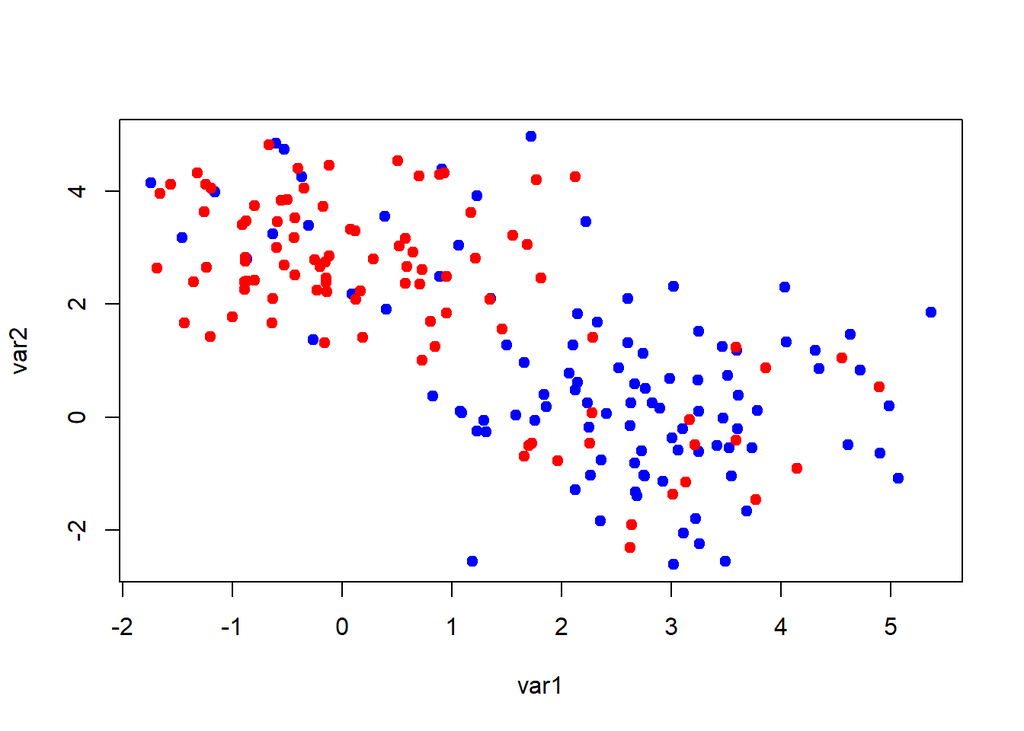

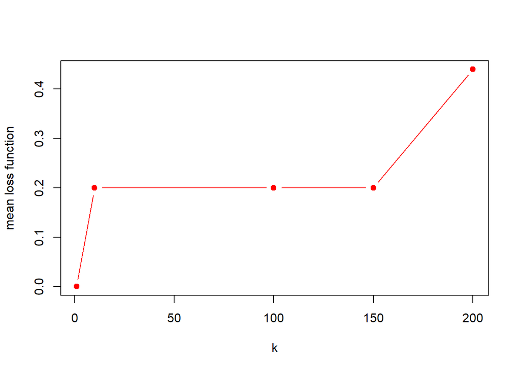

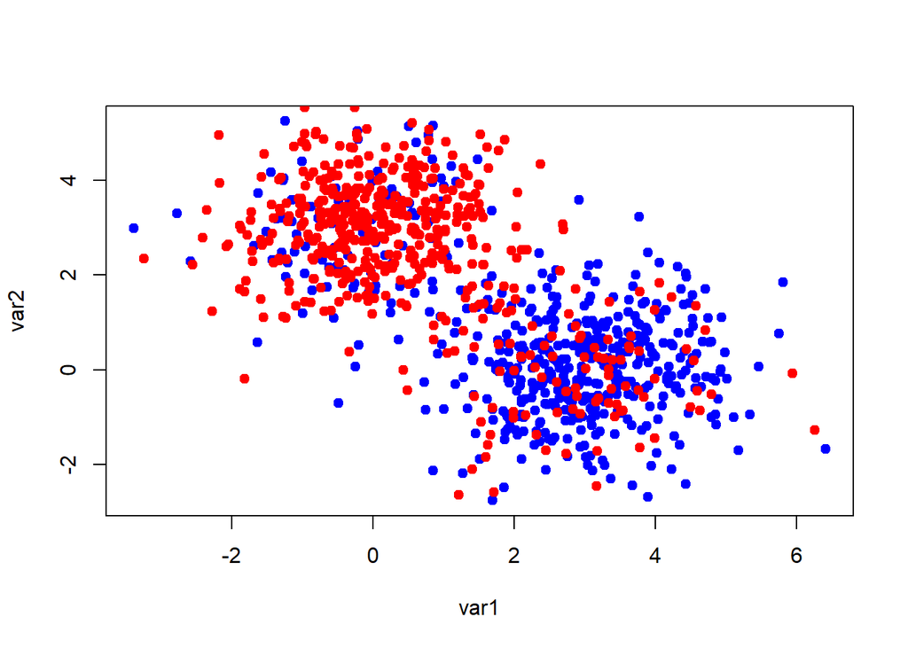

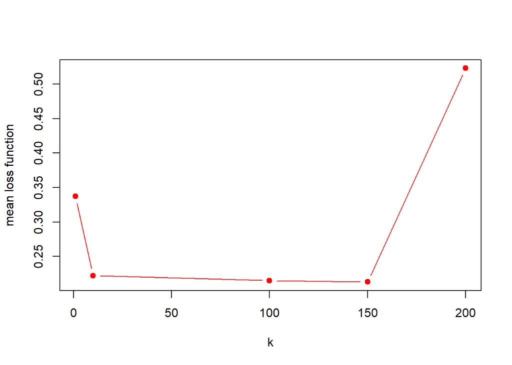

```r
library("MASS")
library(class)                              # for knn

for (i in c(100,500)) {
  n1 <- i*0.8 # Specify sample size
  n2 <- i*0.2

  mean1 <- c(3,0)                                  # Specify the means of the variables
  mean2 <- c(0,3)
  covar_mat <- matrix(c(1, 0, 0, 1),                 # Specify the covariance matrix of the variables
                      ncol = 2)

  data1 = mvrnorm(n = n1, mu = mean1, Sigma = covar_mat)
  data2 = mvrnorm(n = n2, mu = mean2, Sigma = covar_mat)

  data3 = mvrnorm(n = n1, mu = mean2, Sigma = covar_mat)
  data4 = mvrnorm(n = n2, mu = mean1, Sigma = covar_mat)

  data_blue1 = rbind(data1, data2)                    # rbind - row-wise bind , cbind - column-wise bind
  data_red1 = rbind(data3, data4)

  data_final1 = rbind(data_blue1,data_red1)


  Y_blue = matrix(0, i, 1)
  Y_red = matrix(1,i,1)
  Y_final1 = rbind(Y_blue,Y_red)

  data_all1 = cbind(data_final1,Y_final1)

  nam <- paste("data_all", i, sep = "")                         # dynamic naming
  assign(nam, data_all1[sample(nrow(data_all1)),])              # randomly arranging the data


  plot(data_blue1, col = "blue" , pch= 19, xlab = "var1",ylab="var2")

  points(data_red1, col = "red" , pch = 19 )           # cant combine , therefore using points

  misClassError = NULL
  if(i==100){test1 = data_all100[,1:2]; actual = data_all100[,3]}
  else {test1 = data_all500[,1:2]; actual = data_all500[,3]}

  for (e in c(1,10,100,150,200)) {
    classifier_knn_i <- knn(train = data_all100[,1:2],
                          test = test1,
                          cl = data_all100[,3],
                          k = e)

    classifier_knn = as.numeric(classifier_knn_i)   # converting from factor to numeric
    classifier_knn = classifier_knn - 1     # classifier giving 1 and 2 as output, therefore making it to 0 and 1


    misClassError1 <- sum((classifier_knn - actual)^2)/(2*i)

    misClassError = c(misClassError, misClassError1)


  }

  plot(c(1,10,100,150,200),misClassError,xlab = "k", ylab = "mean loss function",type ="b",pch = 19, col = "red")

}
```

## Q6 a)

```r
data6 <- read.csv("D:/Downloads/data6.csv")
model<-lm(y ~ x1 + x2 + x3 + cat_variable + x7, data=data6)
summary(model)    # p-values
```

```
##
## Call:
## lm(formula = y ~ x1 + x2 + x3 + cat_variable + x7, data = data6)
##
## Residuals:
##      Min       1Q   Median       3Q      Max
## -1.18915 -0.32707 -0.08482  0.44561  1.03860
##
## Coefficients:
##               Estimate Std. Error t value Pr(>|t|)
## (Intercept)  -0.059856   0.120195  -0.498    0.619
## x1            2.014998   0.037054  54.380   <2e-16 ***
## x2            1.029822   0.038734  26.587   <2e-16 ***
## x3           -0.005762   0.033408  -0.172    0.863
## cat_variable  1.757129   0.048910  35.926   <2e-16 ***
## x7           -0.004239   0.034891  -0.121    0.903
## ---
## Signif. codes:  0 '***' 0.001 '**' 0.01 '*' 0.05 '.' 0.1 ' ' 1
##
## Residual standard error: 0.4952 on 194 degrees of freedom
## Multiple R-squared:  0.9621, Adjusted R-squared:  0.9611
## F-statistic: 985.4 on 5 and 194 DF,  p-value: < 2.2e-16
```

From above, **p-value: < 2.2e-16**

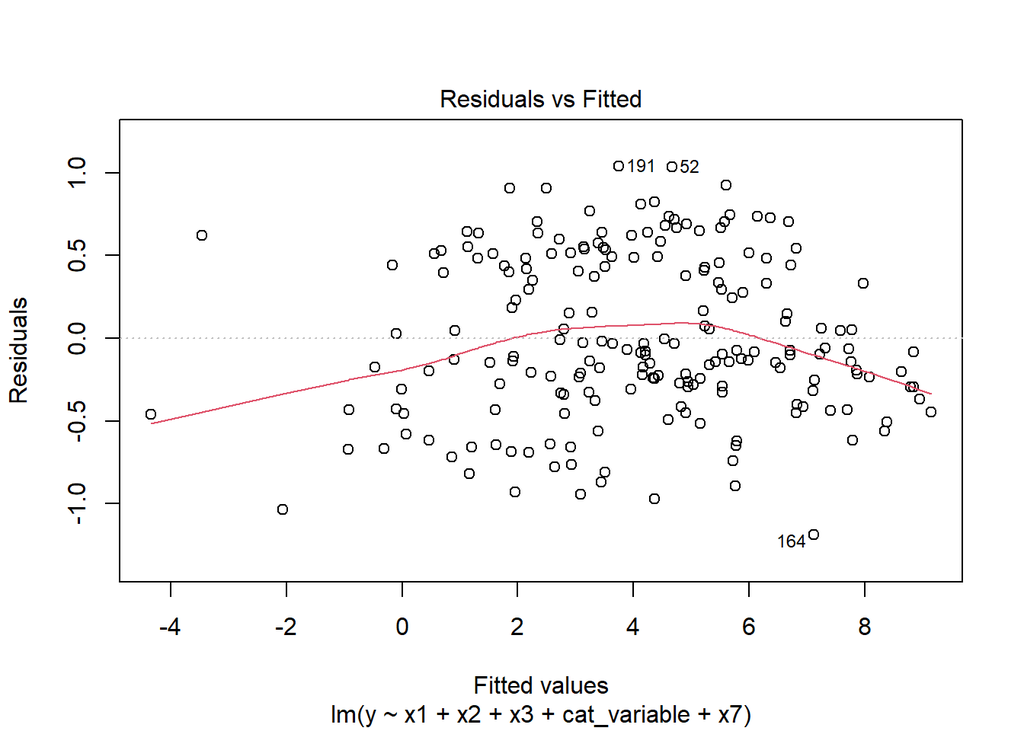

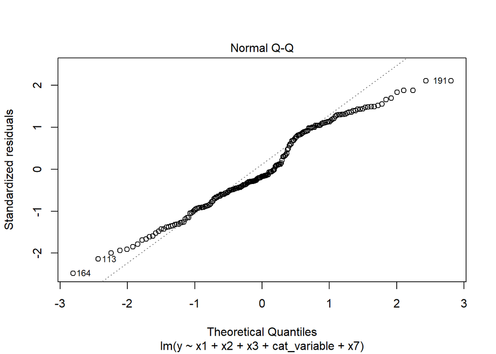

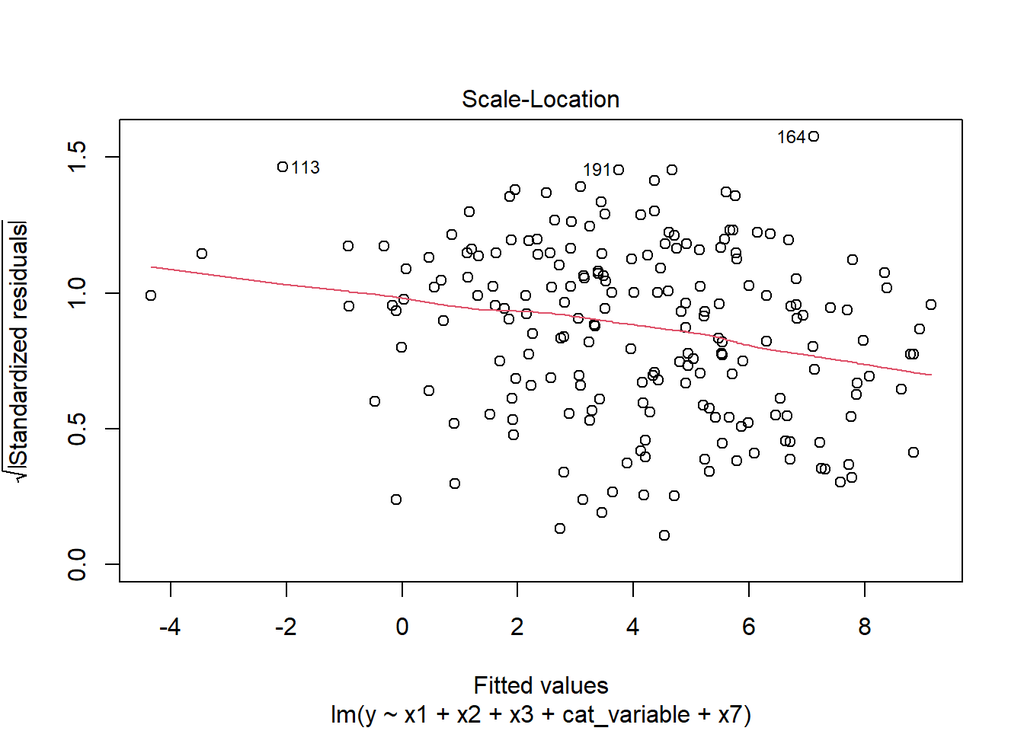

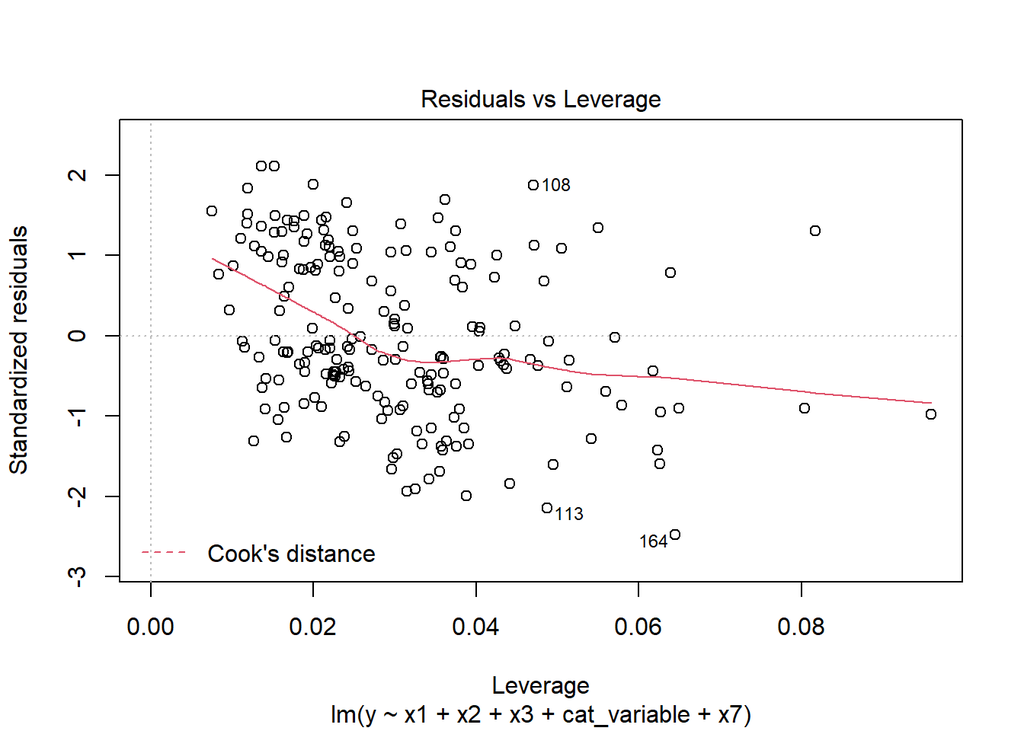

```r
plot(model)       # residual plots
```

```r
confint(model)    #confindence intervals
```

```
##                    2.5 %     97.5 %
## (Intercept)  -0.29691367 0.17720162
## x1            1.94191739 2.08807954
## x2            0.95342774 1.10621526
## x3           -0.07165025 0.06012725
## cat_variable  1.66066526 1.85359198
## x7           -0.07305318 0.06457599
```

By seeing coefficients **x1,cat_variable,x2** are statistically significant

### b)

```r
#perform forward stepwise regression
min_model <-lm(y ~ x1, data = data6)
forward <- step(min_model, direction='forward', scope=formula(model), trace=0)
#view results of forward stepwise regression
forward$anova
```

```
##             Step Df Deviance Resid. Df Resid. Dev        AIC
## 1                NA       NA       198  511.41467  191.77268
## 2 + cat_variable -1 288.2064       197  223.20830   27.95761
## 3           + x2 -1 175.6207       196   47.58761 -279.14899
```

```r
#view final model
forward$coefficients
```

```
##  (Intercept)           x1 cat_variable           x2
##  -0.05867073   2.01530993   1.75675324   1.03065663
```

## Q7

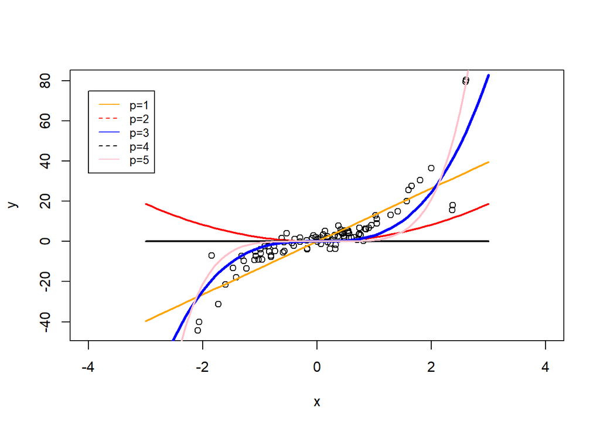

```r
data7 = read.csv("D:/Downloads/data7.csv")
x1 = seq(-3, 3, by=0.1)
model1 <- lm(data7[,2] ~ poly(data7[,3],1, raw = TRUE))
model2 <- lm(data7[,2] ~ poly(data7[,3],2, raw = TRUE))
model3 <- lm(data7[,2] ~ poly(data7[,3],3, raw = TRUE))
model4 <- lm(data7[,2] ~ poly(data7[,3],4, raw = TRUE))
model5 <- lm(data7[,2] ~ poly(data7[,3],5, raw = TRUE))

plot(data7[,3],data7[,2] ,xlab = "x", ylab="y", xlim = c(-4,4))
for (q in 1:5){
  for (i in 0:q) {
    if(q==1){model = model1
    color = "orange"}
    else if(q==2){model = model2
    color = "red"}
    else if(q==3){model = model3
    color="blue"}
    else if(q==4){model = model4
    color = "black"}
    else if(q==5){model = model5
    color = "pink"}
    y_fitted = model$coefficients[i+1]*x1^i

  }
  if(q ==3){lwd = 3} else lwd =2
  points(x1,y_fitted , col = color , type = "l",lwd = lwd)
}

legend(-4, 75, legend=c("p=1","p=2","p=3","p=4","p=5"),
       col=c("orange","red","blue","black","pink"), lty=1:2, cex=0.8)
```

We can see that for **p=3**, model is best fitted.Having **p-value: < 2.2e-16**

```r
summary(model3)   #for p = 3
```

```
##
## Call:
## lm(formula = data7[, 2] ~ poly(data7[, 3], 3, raw = TRUE))
##
## Residuals:
##     Min      1Q  Median      3Q     Max
## -32.092  -2.100   0.304   1.968  20.286
##
## Coefficients:
##                                  Estimate Std. Error t value Pr(>|t|)
## (Intercept)                        1.0886     0.8118   1.341  0.18309
## poly(data7[, 3], 3, raw = TRUE)1   3.9128     1.2000   3.261  0.00154 **
## poly(data7[, 3], 3, raw = TRUE)2  -0.6147     0.5523  -1.113  0.26853
## poly(data7[, 3], 3, raw = TRUE)3   3.0727     0.3605   8.524 2.19e-13 ***
## ---
## Signif. codes:  0 '***' 0.001 '**' 0.01 '*' 0.05 '.' 0.1 ' ' 1
##
## Residual standard error: 6.362 on 96 degrees of freedom
## Multiple R-squared:  0.844,  Adjusted R-squared:  0.8392
## F-statistic: 173.2 on 3 and 96 DF,  p-value: < 2.2e-16
```

## Q8

```r
library(car)
data8 = read.csv("D:/Downloads/data8.csv")

y = data8[,2]
x1 = data8[,3]
x2 = data8[,4]
relation1 <- lm(y3~V2+V3, data=data8)

summary(relation1)
```

```
##
## Call:
## lm(formula = y3 ~ V2 + V3, data = data8)
##
## Residuals:
##     Min      1Q  Median      3Q     Max
## -0.8540 -0.2238 -0.0946  0.0591  9.8335
##
## Coefficients:
##             Estimate Std. Error t value Pr(>|t|)
## (Intercept)  1.10466    0.06580   16.79   <2e-16 ***
## V2           2.00447    0.07261   27.61   <2e-16 ***
## V3           2.90150    0.07825   37.08   <2e-16 ***
## ---
## Signif. codes:  0 '***' 0.001 '**' 0.01 '*' 0.05 '.' 0.1 ' ' 1
##
## Residual standard error: 0.9272 on 197 degrees of freedom
## Multiple R-squared:  0.948,  Adjusted R-squared:  0.9474
## F-statistic:  1794 on 2 and 197 DF,  p-value: < 2.2e-16
```

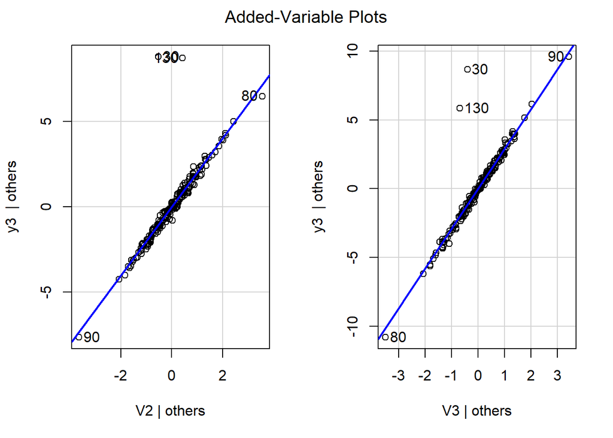

```r
avPlots(relation1)
```

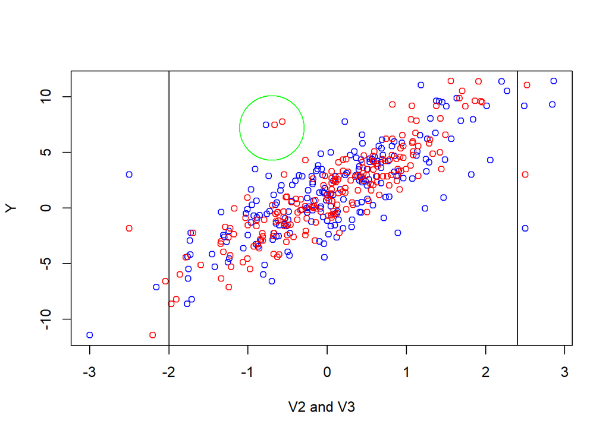

```r
plot(data8[,3],data8[,2] , col = "blue", xlab = "V2 and V3", ylab = "Y")
points(data8[,4],data8[,2], col="red")
abline(v=-2)
abline(v=2.4)
points(-0.7,7.2, cex=10, col = "green")
```

The points inside green circle are **outliers**

The points towards left and right of X = -2 and X = 2.4 respectivly are **leverage points**